# Chapter 4 Clustering and classification

*Summary of the week (completed work and learning)*

In this Chapter We cover two parts:

- Data analysis: we analyze the Boston data from the MASS package using a linear discriminant analysis on the train set.
- Data wrangling: we create a new R script called create_human.R, “Human development” and “Gender inequality” data into R.

### Part 1: data analysis

In this part, We use the following R packages:

```r
library(ggplot2) # to produce plots
library(GGally)
library(ggpubr)  # this is to combine plots in one frame
library(dplyr)
library(tidyr)   # to plot multiple densities and histograms
library(caret)   # to perform cross validations
```

We then proceed by firstly run the R script, print some outputs and then read the outputs.

## 4.1 Explore the data

We load the Boston data from the MASS package and look at the structure as well as the summary as follows:

```r
# access the MASS package
library(MASS)
```

```r
# load the data
data("Boston")
str(Boston) # explore the structure
```

```
## 'data.frame':    506 obs. of  14 variables:
##  $ crim   : num  0.00632 0.02731 0.02729 0.03237 0.06905 ...
##  $ zn     : num  18 0 0 0 0 0 12.5 12.5 12.5 12.5 ...
##  $ indus  : num  2.31 7.07 7.07 2.18 2.18 2.18 7.87 7.87 7.87 7.87 ...
##  $ chas   : int  0 0 0 0 0 0 0 0 0 0 ...
##  $ nox    : num  0.538 0.469 0.469 0.458 0.458 0.458 0.524 0.524 0.524 0.524 ...
##  $ rm     : num  6.58 6.42 7.18 7 7.15 ...
##  $ age    : num  65.2 78.9 61.1 45.8 54.2 58.7 66.6 96.1 100 85.9 ...
##  $ dis    : num  4.09 4.97 4.97 6.06 6.06 ...
##  $ rad    : int  1 2 2 3 3 3 5 5 5 5 ...
##  $ tax    : num  296 242 242 222 222 222 311 311 311 311 ...
##  $ ptratio: num  15.3 17.8 17.8 18.7 18.7 18.7 15.2 15.2 15.2 15.2 ...
##  $ black  : num  397 397 393 395 397 ...
##  $ lstat  : num  4.98 9.14 4.03 2.94 5.33 ...
##  $ medv   : num  24 21.6 34.7 33.4 36.2 28.7 22.9 27.1 16.5 18.9 ...
```

```r
summary(Boston) #print summary
```

```
##       crim                zn             indus            chas
##  Min.   : 0.00632   Min.   :  0.00   Min.   : 0.46   Min.   :0.00000
##  1st Qu.: 0.08205   1st Qu.:  0.00   1st Qu.: 5.19   1st Qu.:0.00000
##  Median : 0.25651   Median :  0.00   Median : 9.69   Median :0.00000
##  Mean   : 3.61352   Mean   : 11.36   Mean   :11.14   Mean   :0.06917
##  3rd Qu.: 3.67708   3rd Qu.: 12.50   3rd Qu.:18.10   3rd Qu.:0.00000
##  Max.   :88.97620   Max.   :100.00   Max.   :27.74   Max.   :1.00000
##       nox               rm             age              dis
##  Min.   :0.3850   Min.   :3.561   Min.   :  2.90   Min.   : 1.130
##  1st Qu.:0.4490   1st Qu.:5.886   1st Qu.: 45.02   1st Qu.: 2.100
##  Median :0.5380   Median :6.208   Median : 77.50   Median : 3.207
##  Mean   :0.5547   Mean   :6.285   Mean   : 68.57   Mean   : 3.795
##  3rd Qu.:0.6240   3rd Qu.:6.623   3rd Qu.: 94.08   3rd Qu.: 5.188
##  Max.   :0.8710   Max.   :8.780   Max.   :100.00   Max.   :12.127
##       rad              tax           ptratio          black
##  Min.   : 1.000   Min.   :187.0   Min.   :12.60   Min.   :  0.32
##  1st Qu.: 4.000   1st Qu.:279.0   1st Qu.:17.40   1st Qu.:375.38
##  Median : 5.000   Median :330.0   Median :19.05   Median :391.44
##  Mean   : 9.549   Mean   :408.2   Mean   :18.46   Mean   :356.67
##  3rd Qu.:24.000   3rd Qu.:666.0   3rd Qu.:20.20   3rd Qu.:396.23
##  Max.   :24.000   Max.   :711.0   Max.   :22.00   Max.   :396.90
##      lstat            medv
##  Min.   : 1.73   Min.   : 5.00
##  1st Qu.: 6.95   1st Qu.:17.02
##  Median :11.36   Median :21.20
##  Mean   :12.65   Mean   :22.53
##  3rd Qu.:16.95   3rd Qu.:25.00
##  Max.   :37.97   Max.   :50.00
```

**Brief description about the dataset**

This is data of housing Values in Suburbs of Boston. We have 506 observations of 14 variables which the description of each variabel in details can be seen here: https://stat.ethz.ch/R-manual/R-devel/library/MASS/html/Boston.html. From the summary, we can see that there is a wide range of different scales of the variables in the dataset.

## 4.2 Graphical overview

Here, we show a graphical overview of the data. We especially look at the distributions and correlations between the variables. From the histograms and density plots, most variables are not normally distributed and most feature long tails. Among all variables, ‘medv’ and ‘rm’ seem normally distributed. Then from the correlograms, some variables pose a high degree of correlations, both positive and negative correlations. The positive correlations are highlighted by reds, while negative correlations are highlighted with blues. The highest positive correlation is between ‘rad’ and ‘tax’ (0.91) and the highest negative correlation is between ‘nox’ and ‘dis’ (0.77).

```r
data <- Boston %>%                          # Apply pivot_longer function
  pivot_longer(colnames(Boston)) %>%
  as.data.frame()
head(data)                                # Print head of data
```

```
##    name    value
## 1  crim  0.00632
## 2    zn 18.00000
## 3 indus  2.31000
## 4  chas  0.00000
## 5   nox  0.53800
## 6    rm  6.57500
```

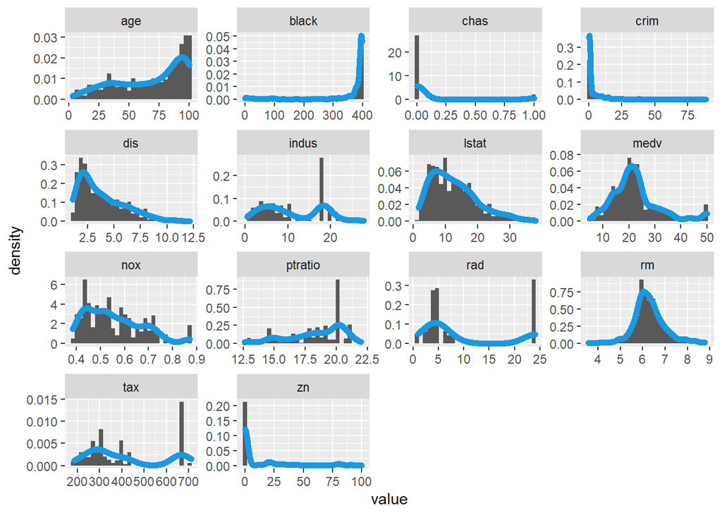

```r
ggp <- ggplot(data, aes(x = value)) +    # Draw histogram & density
  geom_histogram(aes(y = ..density..)) +
  geom_density(col = "#1b98e0", size = 2) +
  facet_wrap(~ name, scales = "free")
ggp
```

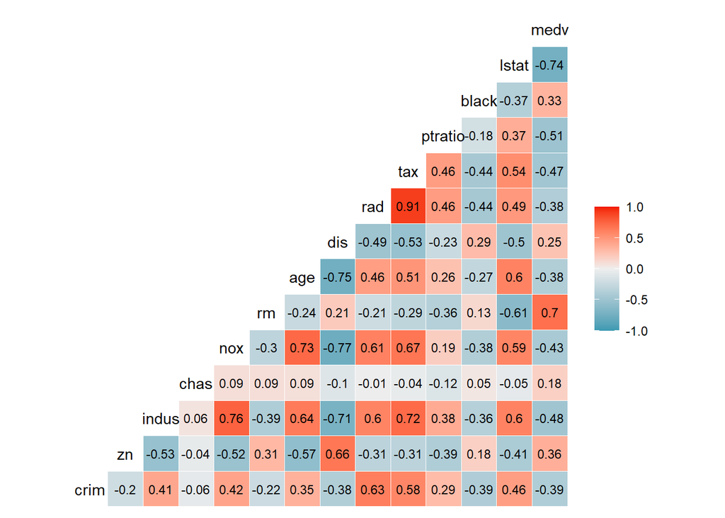

```r
ggcorr(Boston[colnames(Boston) != "gender"], palette = "RdBu", label = TRUE, label_round=2, label_size = 3)
```

## 4.3 Standardize the dataset

We standardize the dataset and print out summaries of the scaled data. From the summary below, we can now see that the means of the variables are all zeros.

```r
data_scaled <- scale(Boston) # Use the standardize package
summary(data_scaled)
```

```
##       crim                 zn               indus              chas
##  Min.   :-0.419367   Min.   :-0.48724   Min.   :-1.5563   Min.   :-0.2723
##  1st Qu.:-0.410563   1st Qu.:-0.48724   1st Qu.:-0.8668   1st Qu.:-0.2723
##  Median :-0.390280   Median :-0.48724   Median :-0.2109   Median :-0.2723
##  Mean   : 0.000000   Mean   : 0.00000   Mean   : 0.0000   Mean   : 0.0000
##  3rd Qu.: 0.007389   3rd Qu.: 0.04872   3rd Qu.: 1.0150   3rd Qu.:-0.2723
##  Max.   : 9.924110   Max.   : 3.80047   Max.   : 2.4202   Max.   : 3.6648
##       nox                rm               age               dis
##  Min.   :-1.4644   Min.   :-3.8764   Min.   :-2.3331   Min.   :-1.2658
##  1st Qu.:-0.9121   1st Qu.:-0.5681   1st Qu.:-0.8366   1st Qu.:-0.8049
##  Median :-0.1441   Median :-0.1084   Median : 0.3171   Median :-0.2790
##  Mean   : 0.0000   Mean   : 0.0000   Mean   : 0.0000   Mean   : 0.0000
##  3rd Qu.: 0.5981   3rd Qu.: 0.4823   3rd Qu.: 0.9059   3rd Qu.: 0.6617
##  Max.   : 2.7296   Max.   : 3.5515   Max.   : 1.1164   Max.   : 3.9566
##       rad               tax             ptratio            black
##  Min.   :-0.9819   Min.   :-1.3127   Min.   :-2.7047   Min.   :-3.9033
##  1st Qu.:-0.6373   1st Qu.:-0.7668   1st Qu.:-0.4876   1st Qu.: 0.2049
##  Median :-0.5225   Median :-0.4642   Median : 0.2746   Median : 0.3808
##  Mean   : 0.0000   Mean   : 0.0000   Mean   : 0.0000   Mean   : 0.0000
##  3rd Qu.: 1.6596   3rd Qu.: 1.5294   3rd Qu.: 0.8058   3rd Qu.: 0.4332
##  Max.   : 1.6596   Max.   : 1.7964   Max.   : 1.6372   Max.   : 0.4406
##      lstat              medv
##  Min.   :-1.5296   Min.   :-1.9063
##  1st Qu.:-0.7986   1st Qu.:-0.5989
##  Median :-0.1811   Median :-0.1449
##  Mean   : 0.0000   Mean   : 0.0000
##  3rd Qu.: 0.6024   3rd Qu.: 0.2683
##  Max.   : 3.5453   Max.   : 2.9865
```

```r
#create a categorical crime rate variable
newcrime <- as.factor(ifelse(data_scaled[1:506, 1] < 0.08205, 'A',
                          ifelse(data_scaled[1:506, 1] < 0.25651, 'B',
                          ifelse(data_scaled[1:506, 1] < 3.61352, 'C',
                          ifelse(data_scaled[1:506, 1] < 3.67708, 'D',0)))))

newdata <- data.frame(newcrime, data_scaled[1:506, 2:14]) # Drop the old crime rate variable & put the new variable into it.
# divide the dataset to train and test sets
## 80% of the sample size
smp_size <- floor(0.80 * nrow(newdata))

## set the seed to make partition reproducible
set.seed(1235)
train_ind <- sample(seq_len(nrow(newdata)), size = smp_size)

train <- newdata[train_ind, ]
test <- newdata[-train_ind, ]
```

## 4.4 Fit the linear discriminant analysis on the train set

Next, we fit a linear discriminant analysis on the train set. We use the categorical crime rate as the target variable and all the other variables in the dataset as predictor variables. We then draw the LDA (bi)plot.

```r
model <- lda(train$newcrime~., data = train)
model
```

```
## Call:
## lda(train$newcrime ~ ., data = train)
##
## Prior probabilities of groups:
##           0           A           B           C
## 0.007425743 0.789603960 0.039603960 0.163366337
##
## Group means:
##           zn      indus        chas        nox          rm        age
## 0 -0.4872402  1.0149946 -0.27232907  0.8368446 -0.44495696  0.8641592
## A  0.1336046 -0.3074741  0.01153709 -0.3266531  0.07706802 -0.2555039
## B -0.4872402  1.0149946 -0.02626030  0.8861063 -0.25264027  0.6137051
## C -0.4872402  1.0149946 -0.15302300  1.0431750 -0.40098715  0.8398297
##          dis        rad        tax    ptratio      black       lstat       medv
## 0 -0.9983375  1.6596029  1.5294129  0.8057784 -3.7685657  0.34032337 -1.1923470
## A  0.2721614 -0.5181641 -0.4588378 -0.2225764  0.2409408 -0.24996379  0.1842050
## B -0.6564289  1.6596029  1.5294129  0.8057784 -0.1946129  0.06643785  0.1731190
## C -0.8858137  1.6596029  1.5294129  0.8057784 -0.9293838  1.10432149 -0.8534722
##
## Coefficients of linear discriminants:
##                  LD1         LD2          LD3
## zn      -0.187111412  0.24260931 -0.058642313
## indus   -0.031929123 -0.23656445  0.299270312
## chas     0.129543544  0.05438082 -0.038986051
## nox      0.328508883 -0.51159946 -0.129243467
## rm      -0.205858348  0.38530001 -0.841695471
## age     -0.010595434 -0.04852834  0.542508694
## dis      0.314054651 -0.70324882  0.286884652
## rad     -2.560614330 -0.17587934 -0.006270611
## tax     -0.011416877 -0.33412105  0.068607228
## ptratio  0.008397258 -0.20252082  0.091169960
## black    0.123918755 -0.80259514 -0.747245493
## lstat   -0.263170522  0.01475087 -1.369044498
## medv     0.188586691 -1.02960331  0.463123736
##
## Proportion of trace:
##    LD1    LD2    LD3
## 0.9580 0.0255 0.0165
```

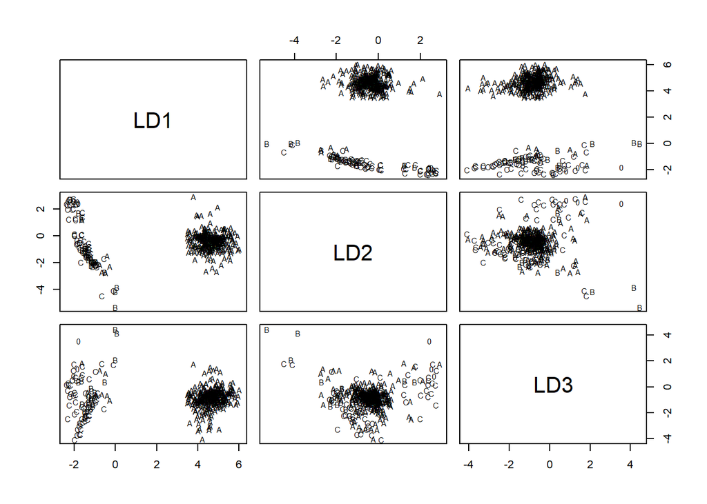

```r
# Draw the LDA (bi)plot
plot(model)
```

## 4.5 Predict with the LDA model

Here, we save the crime categories from the test set and then remove the categorical crime variable from the test dataset. We then predict the classes with the LDA model on the test data and cross tabulate the results with the crime categories from the test set.

```r
# save the crime categories from the test set
crime_test <- test$newcrime
# remove the categorical crime variable from the test dataset.
test <- subset(test, select = -newcrime)
# predict the classes with the LDA model
predictions <- model %>% predict(test)
# cross tabulate the results
table(predictions$class, crime_test)
```

```
##    crime_test
##      0  A  B  C
##   0  0  0  1  2
##   A  0 65  0  0
##   B  0  1  2  2
##   C  5  4  2 18
```

Based on the prediction results above, we have 18+65+2=85 correct predictions or accuracy of 83.33%, hence the error is about 16.67%.

## 4.6 Run k-means algorithm

Here, we reload the Boston dataset and standardize the dataset. We then calculate the distances between the observations. The computation of the distances below is based on Euclidean distance. The visualization is the visualization of the distance matrix which seems posing too large dimensions.

```r
# reload data and standardize
data("Boston")
data <- scale(Boston) # Use the standardize package
```

```r
library(tidyverse)  # for data manipulation
library(cluster)    # for clustering algorithms
library(factoextra) # for clustering algorithms & visualization
```

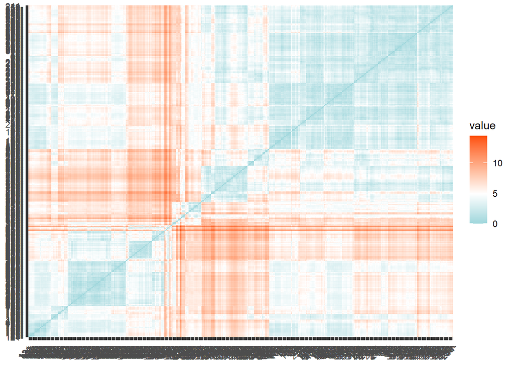

```r
distance <- get_dist(data)
fviz_dist(distance, gradient = list(low = "#00AFBB", mid = "white", high = "#FC4E07"))
```

We now run k-means algorithm on the dataset and investigate what is the optimal number of clusters and run the algorithm again. We adopt some R packages from here: https://uc-r.github.io/kmeans_clustering#distance.

```r
k2 <- kmeans(data, centers = 2, nstart = 25) # k=2 clusters
k3 <- kmeans(data, centers = 3, nstart = 25) # k=3 clusters
k4 <- kmeans(data, centers = 4, nstart = 25) # k=4 clusters
k5 <- kmeans(data, centers = 5, nstart = 25) # k=5 clusters
str(k2)
```

```
## List of 9
##  $ cluster     : Named int [1:506] 2 2 2 2 2 2 2 2 2 2 ...
##   ..- attr(*, "names")= chr [1:506] "1" "2" "3" "4" ...
##  $ centers     : num [1:2, 1:14] 0.724 -0.389 -0.487 0.262 1.143 ...
##   ..- attr(*, "dimnames")=List of 2
##   .. ..$ : chr [1:2] "1" "2"
##   .. ..$ : chr [1:14] "crim" "zn" "indus" "chas" ...
##  $ totss       : num 7070
##  $ withinss    : num [1:2] 1891 2686
##  $ tot.withinss: num 4577
##  $ betweenss   : num 2493
##  $ size        : int [1:2] 177 329
##  $ iter        : int 1
##  $ ifault      : int 0
##  - attr(*, "class")= chr "kmeans"
```

We continue to visualize the clusters. The visualization tells us where true dilineations occur. To evaluate further what the optimal number of clusters is, we rely on the so-called “Average Silhouette Method”. In short, the method measures how well each object lies within its cluster. A high average silhouette width indicates a good clustering. Based on the results, we find that the optimum number of clusters is 2.

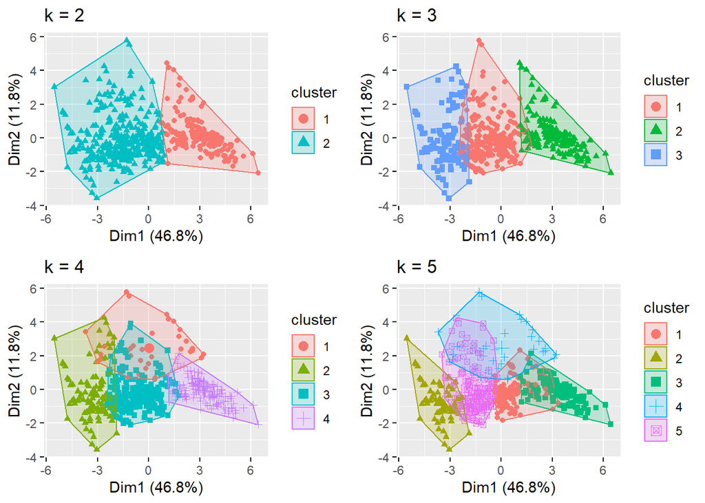

```r
# plots to compare
p1 <- fviz_cluster(k2, geom = "point", data = data) + ggtitle("k = 2")
p2 <- fviz_cluster(k3, geom = "point",  data = data) + ggtitle("k = 3")
p3 <- fviz_cluster(k4, geom = "point",  data = data) + ggtitle("k = 4")
p4 <- fviz_cluster(k5, geom = "point",  data = data) + ggtitle("k = 5")

library(gridExtra)
grid.arrange(p1, p2, p3, p4, nrow = 2)
```

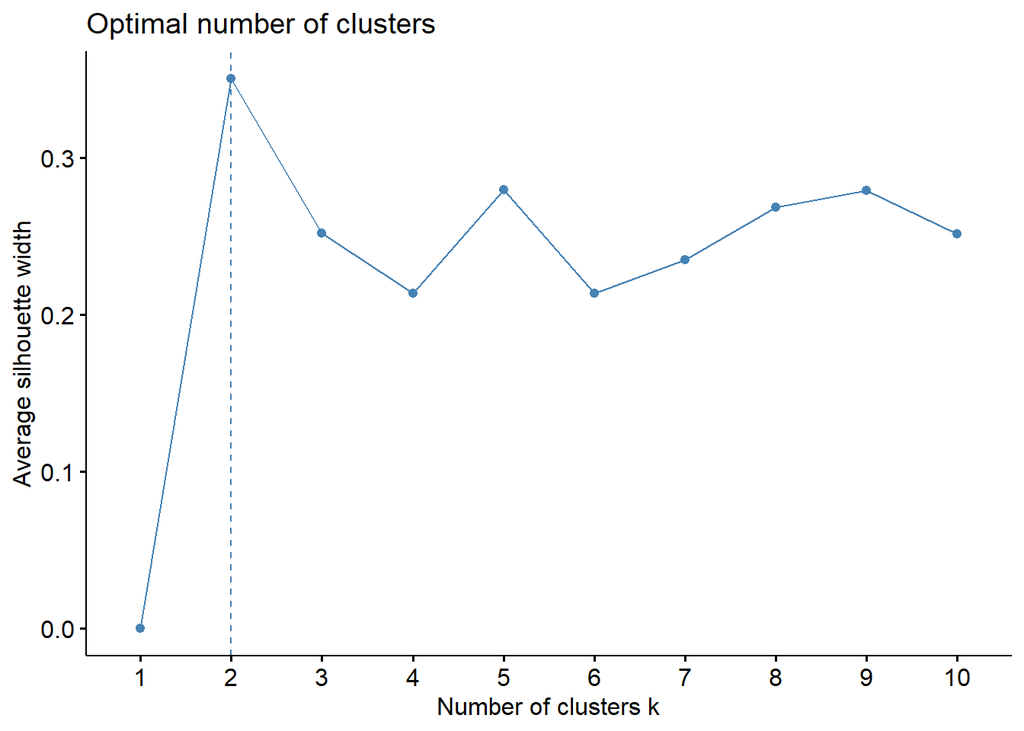

```r
fviz_nbclust(data, kmeans, method = "silhouette")
```

### Part 2: data wrangling

We create a new R script called create_human.R here: https://github.com/alfanmansur/IODS-project/blob/master/data/create_human.R

*This is the end of the report*

```r
date()
```

```
## [1] "Thu Nov 25 16:35:02 2021"
```